# Introduction to Computer Vision: Plant Seedlings Classification

## Problem Statement

### Context

In recent times, the field of agriculture has been in urgent need of modernizing, since the amount of manual work people need to put in to check if plants are growing correctly is still highly extensive. Despite several advances in agricultural technology, people working in the agricultural industry still need to have the ability to sort and recognize different plants and weeds, which takes a lot of time and effort in the long term. The potential is ripe for this trillion-dollar industry to be greatly impacted by technological innovations that cut down on the requirement for manual labor, and this is where Artificial Intelligence can actually benefit the workers in this field, as **the time and energy required to identify plant seedlings will be greatly shortened by the use of AI and Deep Learning.** The ability to do so far more efficiently and even more effectively than experienced manual labor, could lead to better crop yields, the freeing up of human inolvement for higher-order agricultural decision making, and in the long term will result in more sustainable environmental practices in agriculture as well.

### Objective

The aim of this project is to Build a Convolutional Neural Netowrk to classify plant seedlings into their respective categories.

### Data Dictionary

The Aarhus University Signal Processing group, in collaboration with the University of Southern Denmark, has recently released a dataset containing **images of unique plants belonging to 12 different species.**

- The dataset can be download from Olympus.
- The data file names are:
  - images.npy
  - Labels.csv
- Due to the large volume of data, the images were converted to the images.npy file and the labels are also put into Labels.csv, so that you can work on the data/project seamlessly without having to worry about the high data volume.
- The goal of the project is to create a classifier capable of determining a plant's species from an image.

**List of Species**

- Black-grass
- Charlock
- Cleavers
- Common Chickweed
- Common Wheat
- Fat Hen
- Loose Silky-bent
- Maize
- Scentless Mayweed
- Shepherds Purse
- Small-flowered Cranesbill
- Sugar beet

## Importing necessary libraries

```python
# Installing the libraries with the specified version if Google Colab is being used.

!pip install tensorflow==2.15.0 scikit-learn==1.2.2 seaborn==0.13.1 matplotlib==3.7.1 numpy==1.25.2 pandas==1.5.3 opencv-python==4.8.0.76 -q --user
```

```python
# Installing the libraries with the specified version.
# uncomment and run the following lines if Jupyter Notebook is being used
#!pip install tensorflow==2.13.0 scikit-learn==1.2.2 seaborn==0.11.1 matplotlib==3.3.4 numpy==1.24.3 pandas==1.5.2 opencv-python==4.8.0.76 -q --user
```

```python
import os
import numpy as np                                                                               # numpy for Matrix Operations
import pandas as pd                                                                              # pandas to read CSV files
import matplotlib.pyplot as plt                                                                  # matplotlib for Plotting and visualizing images
import math                                                                                      # math module to perform mathematical operations
import cv2                                                                                       # openCV for image processing
import seaborn as sns                                                                            # seaborn to plot graphs


# Tensorflow modules
import tensorflow as tf
from tensorflow.keras.preprocessing.image import ImageDataGenerator                              # ImageDataGenerator for data augmentation
from tensorflow.keras.models import Sequential                                                   # sequential module to define a sequential model
from tensorflow.keras.layers import Dense,Dropout,Flatten,Conv2D,MaxPooling2D,BatchNormalization # Defining all the layers to build our CNN Model
from tensorflow.keras.optimizers import Adam,SGD                                                 # optimizers which will be used in our model
from sklearn import preprocessing                                                                # preprocessing module to preprocess the data
from sklearn.model_selection import train_test_split                                             # train_test_split function to split the data into train and test
from sklearn.metrics import confusion_matrix                                                     # confusion_matrix to plot the confusion matrix
from sklearn.preprocessing import LabelBinarizer
# Display images using OpenCV
from google.colab.patches import cv2_imshow                                                      # cv2_imshow from google.patches to display images
from sklearn.model_selection import train_test_split
from tensorflow.keras import backend
from keras.callbacks import ReduceLROnPlateau
import random
# Ignore warnings
import warnings
warnings.filterwarnings('ignore')
```

```python
# Clearing backend
from tensorflow.keras import backend
backend.clear_session()

# Fixing the seed for random number generators
import random
np.random.seed(42)
random.seed(42)
tf.random.set_seed(42)
```

## Loading the dataset

```python
# Mounting google drive
from google.colab import drive
drive.mount('/content/drive/')
```

```python
# Loading the image file of dataset
images = np.load('/content/drive/MyDrive/Colab Notebooks/images.npy')
```

```python
# Loading the labels file of dataset
labels = pd.read_csv('/content/drive/MyDrive/Labels.csv')
```

## Data Overview

### Understand the shape of the dataset

```python
# View the data shape
print(images.shape)
print(labels.shape)
```

```
(4750, 128, 128, 3)
(4750, 1)
```

The dataset has 4750 image entries each of 128x128 pixel size in 3 color space (RGB format). There are also 4750 corresponding labels.

## Exploratory Data Analysis

### Plotting random images from each of the class

```python
# code to generate images and labels
def plot_images(images,labels):
  num_classes=10                                                                  # Number of Classes
  categories=np.unique(labels)
  keys=dict(labels['Label'])                                                      # Obtaing the unique classes from y_train
  rows = 3                                                                        # Defining number of rows=3
  cols = 4                                                                        # Defining number of columns=4
  fig = plt.figure(figsize=(10, 8))                                               # Defining the figure size to 10x8
  for i in range(cols):
      for j in range(rows):
          random_index = np.random.randint(0, len(labels))                        # Generating random indices from the data and plotting the images
          ax = fig.add_subplot(rows, cols, i * rows + j + 1)                      # Adding subplots with 3 rows and 4 columns
          ax.imshow(images[random_index, :])                                      # Plotting the image
          ax.set_title(keys[random_index])
  plt.show()
```

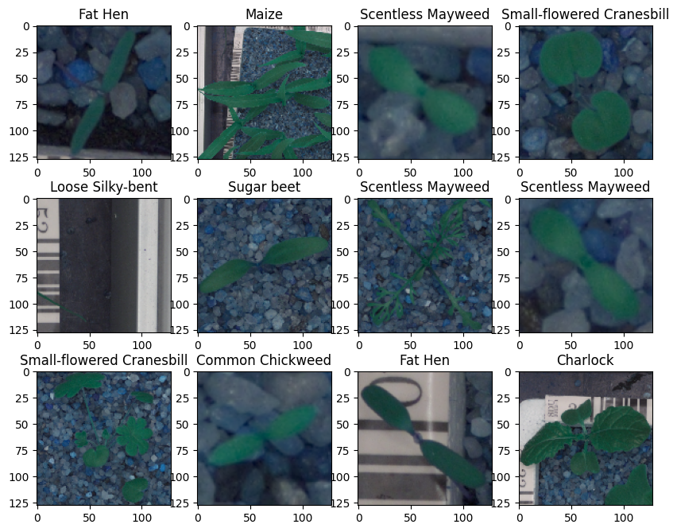

```python
# Input the images and labels to the function and plot the images with their labels
plot_images(images, labels)
```

The images and labels are now linked to the function and the images plotted with their labels

### Checking the distribution of the target variable

[output not shown]

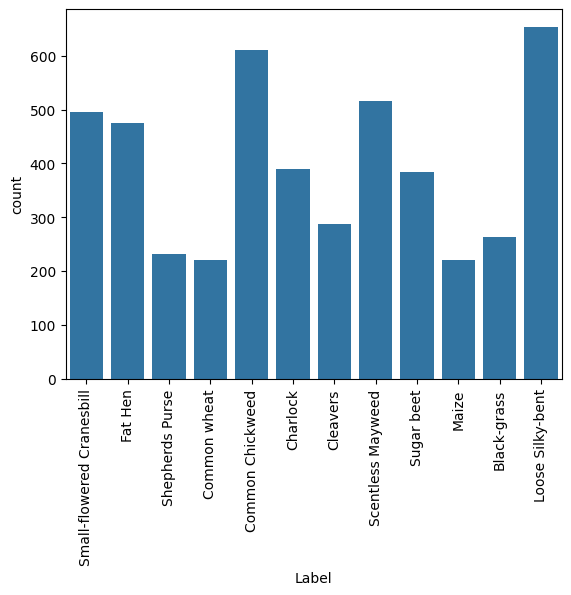

```python
# Viewing data imbalance
sns.countplot(x=labels['Label'])
plt.xticks(rotation='vertical')
```

There is a significant imbalance in the data distribution among the different labels. Loose Silky-bent has the highest count. Common Chickweed also has a high count followed closely by Scentless Mayweed. Small-flowered Cranesbill and Fat Hen have relatively high counts as well. Maize and Shepherds Purse have lower counts compared to the other labels.

## Data Pre-Processing

### Converting the BGR images to RGB images.

```python
# Converting the images from BGR to RGB using cvtColor function of OpenCV
for i in range(len(images)):
  images[i] = cv2.cvtColor(images[i], cv2.COLOR_BGR2RGB)
```

### Resizing images

As the size of the images is large, it may be computationally expensive to train on these larger images; therefore, it is preferable to reduce the image size from 128 to 64.

```python
# reduucing images from size 128 to 64
# defining the height as 64
# defining the width as 64
images_decreased=[]
height = 64
width =  64
dimensions = (width, height)
for i in range(len(images)):
  images_decreased.append( cv2.resize(images[i], dimensions, interpolation=cv2.INTER_LINEAR))
```

The images have been reduced to size 64x64 pixels

**Image before resizing**

```python
# viewing fourth image before resizing
plt.imshow(images[3])
```

[output not shown]

The image size is bigger at 128 x 128 pixels

**Image after resizing**

```python
# viewing fourth image after resizing
plt.imshow(images_decreased[3])
```

[output not shown]

The image size is smaller having been reduced to 64 x 64 pixels

### Data Preparation for Modeling

- As we have less images in our dataset, we will only use 10% of our data for testing, 10% of our data for validation and 80% of our data for training.
- We are using the train_test_split() function from scikit-learn. Here, we split the dataset into three parts, train,test and validation.

```python
# splitting the data with test_size as 0.1
X_temp, X_test, y_temp, y_test = train_test_split(
    np.array(images_decreased),
    np.array(labels),
    test_size=0.1,
    random_state=42,
    stratify=labels
)
```

The data has been split into X and y temp and X and y test datasets for modelling purposes

```python
#splitting the temp data into train data and the validation (test data_size) as 0.1
X_train, X_val, y_train, y_val = train_test_split(
    X_temp,
    y_temp,
    test_size=0.1,
    random_state=42,
    stratify=y_temp
)
```

The temp data set is furthur split into train data set (0.9) and val data set (0.1).

```python
# view the shape of train, validation and test data
print(X_train.shape,y_train.shape)
print(X_val.shape,y_val.shape)
print(X_test.shape,y_test.shape)
```

```
(3847, 64, 64, 3) (3847, 1)
(428, 64, 64, 3) (428, 1)
(475, 64, 64, 3) (475, 1)
```

### Encoding the target labels

```python
# Convert labels from names to one hot vectors.
# We have already used encoding methods like onehotencoder and labelencoder earlier so now we will be using a new encoding method called labelBinarizer.
# Labelbinarizer works similar to onehotencoder

enc = LabelBinarizer()                                     # intialize the labelBinarizer
y_train_encoded = enc.fit_transform(y_train)               # fit and transform y_train
y_val_encoded=enc.transform(y_val)                         # transform y_val
y_test_encoded=enc.transform(y_test)                       # transform y_test
```

Labels have been converted from names to one hot vectors. We have already used encoding methods like onehotencoder and labelencoder earlier so now we will be using a new encoding method called labelBinarizer which works similar to onehotencoder

```python
# view the shape of train, validation and test data
y_train_encoded.shape,y_val_encoded.shape,y_test_encoded.shape
```

```
((3847, 12), (428, 12), (475, 12))
```

The images data arrays have been dumified (onehotencoded/labelbinarized). The numpy arrays data shape of train_encoded is 3847 rows by 12 columns, validation_encoded is 428 rows by 12 columns and test_encoded data is 475 rows by 12 columns.

### Data Normalization

Since the **image pixel values range from 0-255**, our method of normalization here will be **scaling** - we shall **divide all the pixel values by 255 to standardize the images to have values between 0-1.**

```python
# normalize the image pixels of train, test and validation data
X_train_normalized = X_train.astype('float32')/255.0
X_val_normalized = X_val.astype('float32')/255.0
X_test_normalized = X_test.astype('float32')/255.0
```

The encoded X_train, X_Val and X_test data sets have been standardized by normalization.

## Model 1 Building with Adam

```python
# Intializing a sequential model
model1 = Sequential()

# add the first conv layer with 128 filters and kernel size 3x3, padding 'same' provides the output size same as the input size
# Input_shape denotes input image dimension of images
model1.add(Conv2D(128, (3, 3), activation='relu', padding="same", input_shape=(64, 64, 3)))

# add the max pooling to reduce the size of output of first conv layer
model1.add(MaxPooling2D((2, 2), padding = 'same'))

# create two similar convolution and max-pooling layers activation = relu
model1.add(Conv2D(64, (3, 3), activation='relu', padding="same"))
model1.add(MaxPooling2D((2, 2), padding = 'same'))

model1.add(Conv2D(32, (3, 3), activation='relu', padding="same"))
model1.add(MaxPooling2D((2, 2), padding = 'same'))

# flatten the output of the conv layer after max pooling to make it ready for creating dense connections
model1.add(Flatten())

# add a fully connected dense layer with 16 neurons
model1.add(Dense(12, activation='relu'))
model1.add(Dropout(0.3))

# add the output layer with 12 neurons and activation functions as softmax since this is a multi-class classification problem
model1.add(Dense(12, activation='softmax'))

# use the Adam Optimizer
opt=Adam()

# Compile the model using suitable metric for loss fucntion
model1.compile(optimizer=opt, loss='categorical_crossentropy', metrics=['accuracy'])

# generate the summary of the model
model1.summary()
```

```
Model: "sequential"
_________________________________________________________________
 Layer (type)                Output Shape              Param #
=================================================================
 conv2d (Conv2D)             (None, 64, 64, 128)       3584

 max_pooling2d (MaxPooling2  (None, 32, 32, 128)       0
 D)

 conv2d_1 (Conv2D)           (None, 32, 32, 64)        73792

 max_pooling2d_1 (MaxPoolin  (None, 16, 16, 64)        0
 g2D)

 conv2d_2 (Conv2D)           (None, 16, 16, 32)        18464

 max_pooling2d_2 (MaxPoolin  (None, 8, 8, 32)          0
 g2D)

 flatten (Flatten)           (None, 2048)              0

 dense (Dense)               (None, 12)                24588

 dropout (Dropout)           (None, 12)                0

 dense_1 (Dense)             (None, 12)                156

=================================================================
Total params: 120584 (471.03 KB)
Trainable params: 120584 (471.03 KB)
Non-trainable params: 0 (0.00 Byte)
_________________________________________________________________
```

**Fitting the model on the train data**

```python
# fit the model on train and also use the validation data for validation
history_1 = model1.fit(
            X_train_normalized, y_train_encoded,
            epochs=30,
            validation_data=(X_val_normalized,y_val_encoded),
            batch_size=32,
            verbose=2
)
```

```
121/121 - 3s - loss: 2.4552 - accuracy: 0.1149 - val_loss: 2.3798 - val_accuracy: 0.2079 - 3s/epoch - 23ms/step
121/121 - 1s - loss: 2.2290 - accuracy: 0.2641 - val_loss: 2.0270 - val_accuracy: 0.3505 - 1s/epoch - 9ms/step
121/121 - 1s - loss: 2.0196 - accuracy: 0.2979 - val_loss: 1.8326 - val_accuracy: 0.3551 - 1s/epoch - 10ms/step
121/121 - 1s - loss: 1.8930 - accuracy: 0.3202 - val_loss: 1.7305 - val_accuracy: 0.3925 - 1s/epoch - 10ms/step
121/121 - 1s - loss: 1.7873 - accuracy: 0.3670 - val_loss: 1.6445 - val_accuracy: 0.4463 - 1s/epoch - 11ms/step
121/121 - 1s - loss: 1.7440 - accuracy: 0.3715 - val_loss: 1.5161 - val_accuracy: 0.4813 - 1s/epoch - 9ms/step
121/121 - 1s - loss: 1.6674 - accuracy: 0.3982 - val_loss: 1.4537 - val_accuracy: 0.4603 - 1s/epoch - 9ms/step
121/121 - 1s - loss: 1.6245 - accuracy: 0.4203 - val_loss: 1.3793 - val_accuracy: 0.5280 - 1s/epoch - 9ms/step
121/121 - 1s - loss: 1.5901 - accuracy: 0.4263 - val_loss: 1.3968 - val_accuracy: 0.5187 - 1s/epoch - 9ms/step
121/121 - 1s - loss: 1.5428 - accuracy: 0.4333 - val_loss: 1.3818 - val_accuracy: 0.5327 - 1s/epoch - 9ms/step
121/121 - 1s - loss: 1.5431 - accuracy: 0.4331 - val_loss: 1.2956 - val_accuracy: 0.5631 - 1s/epoch - 9ms/step
121/121 - 1s - loss: 1.5025 - accuracy: 0.4539 - val_loss: 1.3524 - val_accuracy: 0.5584 - 1s/epoch - 9ms/step
121/121 - 1s - loss: 1.4927 - accuracy: 0.4572 - val_loss: 1.3146 - val_accuracy: 0.5724 - 1s/epoch - 9ms/step
121/121 - 1s - loss: 1.4462 - accuracy: 0.4645 - val_loss: 1.2783 - val_accuracy: 0.5631 - 1s/epoch - 9ms/step
121/121 - 1s - loss: 1.4342 - accuracy: 0.4747 - val_loss: 1.2079 - val_accuracy: 0.5981 - 1s/epoch - 11ms/step
121/121 - 1s - loss: 1.3862 - accuracy: 0.4856 - val_loss: 1.1510 - val_accuracy: 0.6215 - 1s/epoch - 11ms/step
121/121 - 1s - loss: 1.3659 - accuracy: 0.4955 - val_loss: 1.1380 - val_accuracy: 0.6379 - 1s/epoch - 10ms/step
121/121 - 1s - loss: 1.3538 - accuracy: 0.5053 - val_loss: 1.2059 - val_accuracy: 0.5864 - 1s/epoch - 9ms/step
121/121 - 1s - loss: 1.3381 - accuracy: 0.5108 - val_loss: 1.1140 - val_accuracy: 0.6425 - 1s/epoch - 9ms/step
121/121 - 1s - loss: 1.3241 - accuracy: 0.5160 - val_loss: 1.1171 - val_accuracy: 0.6215 - 1s/epoch - 9ms/step
121/121 - 1s - loss: 1.3030 - accuracy: 0.5183 - val_loss: 1.1113 - val_accuracy: 0.6495 - 1s/epoch - 9ms/step
121/121 - 1s - loss: 1.2646 - accuracy: 0.5334 - val_loss: 1.1232 - val_accuracy: 0.6636 - 1s/epoch - 9ms/step
121/121 - 1s - loss: 1.2658 - accuracy: 0.5425 - val_loss: 1.1362 - val_accuracy: 0.6425 - 1s/epoch - 9ms/step
121/121 - 1s - loss: 1.2809 - accuracy: 0.5334 - val_loss: 1.0786 - val_accuracy: 0.6636 - 1s/epoch - 9ms/step
121/121 - 1s - loss: 1.2424 - accuracy: 0.5435 - val_loss: 1.1103 - val_accuracy: 0.6565 - 1s/epoch - 9ms/step
121/121 - 1s - loss: 1.2251 - accuracy: 0.5586 - val_loss: 1.0661 - val_accuracy: 0.6495 - 1s/epoch - 10ms/step
121/121 - 1s - loss: 1.2040 - accuracy: 0.5571 - val_loss: 1.0752 - val_accuracy: 0.6729 - 1s/epoch - 11ms/step
121/121 - 1s - loss: 1.1972 - accuracy: 0.5633 - val_loss: 1.0861 - val_accuracy: 0.6776 - 1s/epoch - 11ms/step
121/121 - 1s - loss: 1.2159 - accuracy: 0.5597 - val_loss: 1.0977 - val_accuracy: 0.6565 - 1s/epoch - 9ms/step
121/121 - 1s - loss: 1.1889 - accuracy: 0.5578 - val_loss: 1.0813 - val_accuracy: 0.6799 - 1s/epoch - 9ms/step
```

**Model Evaluation**

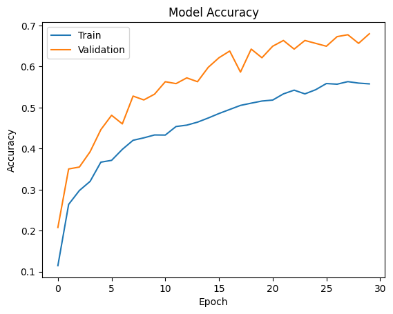

```python
# plotting performance
plt.plot(history_1.history['accuracy'])
plt.plot(history_1.history['val_accuracy'])
plt.title('Model Accuracy')
plt.ylabel('Accuracy')
plt.xlabel('Epoch')
plt.legend(['Train', 'Validation'], loc='upper left')
plt.show()
```

**Evaluating the model on test data**

```python
# evaluate the model on test data
accuracy = model1.evaluate(X_test_normalized, y_test_encoded, verbose=2)
```

```
15/15 - 0s - loss: 1.0493 - accuracy: 0.6568 - 81ms/epoch - 5ms/step
```

**Plotting the Confusion Matrix**

```python
# Here we would get the output as probablities for each category
# predict the output probabilities
y_pred=model1.predict(X_test)
```

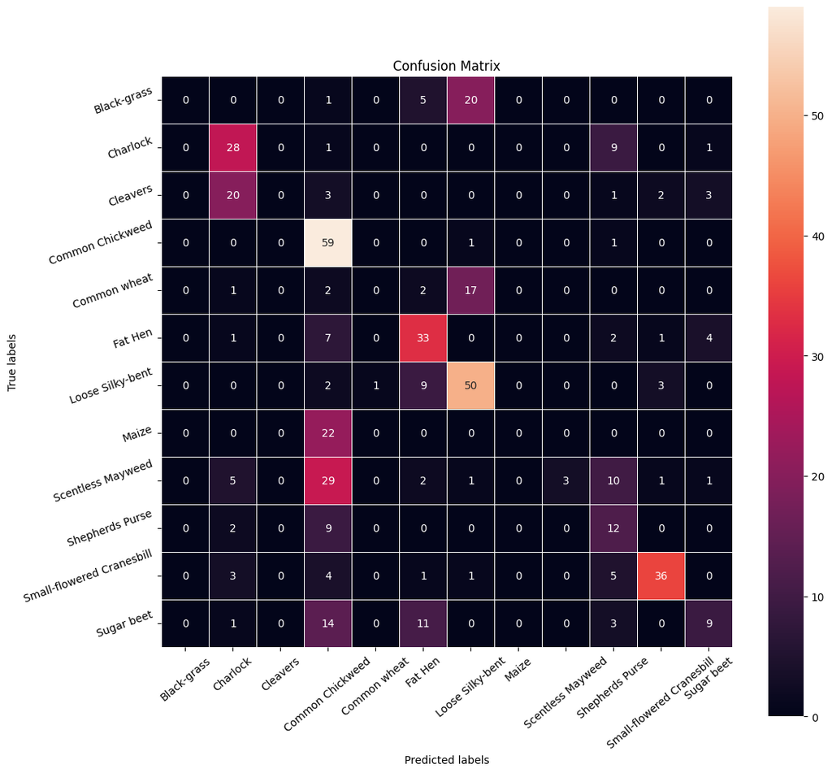

```python
# Obtaining the categorical values from y_test_encoded and y_pred
y_pred_arg=np.argmax(y_pred,axis=1)
y_test_arg=np.argmax(y_test_encoded,axis=1)

# Plotting the Confusion Matrix using confusion matrix() function which is also predefined in tensorflow module
confusion_matrix = tf.math.confusion_matrix(y_test_arg,y_pred_arg)
f, ax = plt.subplots(figsize=(12, 12))
sns.heatmap(
    confusion_matrix,
    annot=True,
    linewidths=.4,
    fmt="d",
    square=True,
    ax=ax
)
# Setting the labels to both the axes
ax.set_xlabel('Predicted labels');ax.set_ylabel('True labels');
ax.set_title('Confusion Matrix');
ax.xaxis.set_ticklabels(list(enc.classes_),rotation=40)
ax.yaxis.set_ticklabels(list(enc.classes_),rotation=20)
plt.show()
```

TIn summary, this confusion matrix reveals that the model performs well for some classes but struggles with others. There are notable misclassifications between certain pairs of classes, indicating that the model might have difficulty distinguishing between them.

The model misclassified some classes, like Cleavers, Maize and Black-grass, suggesting the need for model improvement for those classes. Conversely, Common Chickweed and Small-flowered Cranesbill have high numbers of correct predictions, indicating the model performs well for these classes.ie Black-grass:True Black-grass instances: 0 were correctly classified. Misclassified as: Common Chickweed (1), Fat Hen (5), and Loose Silky-bent (20).

**Plotting Classification Report**

```python
# view accuracy score
import seaborn as sns
from sklearn.metrics import accuracy_score, confusion_matrix
accuracy_score(y_test_arg, y_pred_arg)
```

```
0.4842105263157895
```

The accuracy score on test data without normalization is only 48% which is too low. It is better to normalize labels before training.

```python
# Code to plot the classification report
# Plotting the classification report
# Plotting the classification report
from sklearn.metrics import classification_report
print(classification_report((y_test_arg), y_pred_arg))
```

```
              precision    recall  f1-score   support

           0       0.00      0.00      0.00        26
           1       0.46      0.72      0.56        39
           2       0.00      0.00      0.00        29
           3       0.39      0.97      0.55        61
           4       0.00      0.00      0.00        22
           5       0.52      0.69      0.59        48
           6       0.56      0.77      0.65        65
           7       0.00      0.00      0.00        22
           8       1.00      0.06      0.11        52
           9       0.28      0.52      0.36        23
          10       0.84      0.72      0.77        50
          11       0.50      0.24      0.32        38

    accuracy                           0.48       475
   macro avg       0.38      0.39      0.33       475
weighted avg       0.47      0.48      0.40       475
```

## Model 2: Performance Improvement

**Reducing the Learning Rate:**

**ReduceLRonPlateau()** is a function that will be used to decrease the learning rate by some factor, if the loss is not decreasing for some time. This may start decreasing the loss at a smaller learning rate. There is a possibility that the loss may still not decrease. This may lead to executing the learning rate reduction again in an attempt to achieve a lower loss.

```python
# Clearing backend
from tensorflow.keras import backend
backend.clear_session()

# Fixing the seed for random number generators
import random
np.random.seed(42)
random.seed(42)
tf.random.set_seed(42)
```

```python
# monitor val_accuracy
learning_rate_reduction = ReduceLROnPlateau(monitor='val_accuracy',
                                            patience=3,
                                            verbose=1,
                                            factor=0.5,
                                            min_lr=0.00001)
```

### **Data Augmentation**

Memory has been cleared so it doesnt affect running the next model with learning rate and data augmentation

```python
# to set the rotation_range to 20
train_datagen = ImageDataGenerator(
                              rotation_range=20,
                              fill_mode='nearest'
                              )
```

```python
# Intializing a sequential model
model2 = Sequential()

# add the first conv layer with 64 filters and kernel size 3x3 , padding 'same' provides the output size same as the input size
# Input_shape denotes input image dimension images
model2.add(Conv2D(64, (3,3), activation='relu', padding="same", input_shape=(64, 64, 3)))

# Complete the code to add max pooling to reduce the size of output of first conv layer
model2.add(MaxPooling2D((2, 2), padding = 'same'))

# add the second conv layer with 32 filters and kernel size 3x3, padding 'same' provides the output size same as the input size
model2.add(Conv2D(32, (3, 3), activation='relu', padding="same"))
model2.add(MaxPooling2D((2, 2), padding = 'same'))
model2.add(BatchNormalization())

# flattening the output of the conv layer after max pooling to make it ready for creating dense connections
model2.add(Flatten())

# Adding a fully connected dense layer with 16 neurons
model2.add(Dense(16, activation='relu'))

# add dropout with dropout_rate=0.3
model2.add(Dropout(0.3))
# Complete the code to add the output layer with 12 neurons and activation functions as softmax since this is a multi-class classification problem
model2.add(Dense(12, activation='softmax'))

# initialize Adam Optimimzer
opt=Adam()
# Compile model
model2.compile(optimizer=opt, loss='categorical_crossentropy', metrics=['accuracy'])

# Generate the summary of the model
model2.summary()
```

```
Model: "sequential"
_________________________________________________________________
 Layer (type)                Output Shape              Param #
=================================================================
 conv2d (Conv2D)             (None, 64, 64, 64)        1792

 max_pooling2d (MaxPooling2  (None, 32, 32, 64)        0
 D)

 conv2d_1 (Conv2D)           (None, 32, 32, 32)        18464

 max_pooling2d_1 (MaxPoolin  (None, 16, 16, 32)        0
 g2D)

 batch_normalization (Batch  (None, 16, 16, 32)        128
 Normalization)

 flatten (Flatten)           (None, 8192)              0

 dense (Dense)               (None, 16)                131088

 dropout (Dropout)           (None, 16)                0

 dense_1 (Dense)             (None, 12)                204

=================================================================
Total params: 151676 (592.48 KB)
Trainable params: 151612 (592.23 KB)
Non-trainable params: 64 (256.00 Byte)
_________________________________________________________________
```

The second model has been compiled and it has 151,612 trainable parameters.

**Fitting the model on the train data**

```python
# fit the model on train data with batch_size=64 and epochs=30
# Epochs
epochs = 30
# Batch size
batch_size = 64

history2 = model2.fit(train_datagen.flow(X_train_normalized,y_train_encoded,
                                       batch_size=batch_size,
                                       shuffle=False),
                                       epochs=epochs,
                                       steps_per_epoch=X_train_normalized.shape[0] // batch_size,
                                       validation_data=(X_val_normalized,y_val_encoded),
                                       verbose=1,callbacks=[learning_rate_reduction])
```

```
Epoch 15: ReduceLROnPlateau reducing learning rate to 0.0005000000237487257.
Epoch 23: ReduceLROnPlateau reducing learning rate to 0.0002500000118743628.
Epoch 29: ReduceLROnPlateau reducing learning rate to 0.0001250000059371814.
```

The val loss is much lower than the previous model while the validation acurracy has significantly improved to about 80%. This model has performed better than the previous model.

**Model Evaluation**

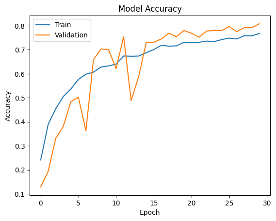

```python
plt.plot(history2.history['accuracy'])
plt.plot(history2.history['val_accuracy'])
plt.title('Model Accuracy')
plt.ylabel('Accuracy')
plt.xlabel('Epoch')
plt.legend(['Train', 'Validation'], loc='upper left')
plt.show()
```

There is a significant improvement in model performance as accuracy is higher then in the previous model. The plot indicates that while the training accuracy is stable and relatively high, the validation accuracy is unstable. This inconsistency suggests that the model might not be learning effectively from the training data.

**Evaluate the model on test data**

```python
 # Complete the code to evaluate the model on test data
accuracy2 = model2.evaluate(X_test_normalized, y_test_encoded, verbose=2)
```

```
15/15 - 0s - loss: 0.6718 - accuracy: 0.7811 - 224ms/epoch - 15ms/step
```

The loss value after the last epoch is 0.672. This metric measures how well the model's predictions match the actual outcomes. Compared to the previous model, this model has lower loss values indicating better performance. The accuracy of the model after the last epoch is 0.7811, meaning the model correctly predicts about 78% of the test data. This model is better than the previous model.

**Plotting the Confusion Matrix**

```python
# to obtain the output probabilities

y_pred2 = model2.predict(X_test_normalized)
```

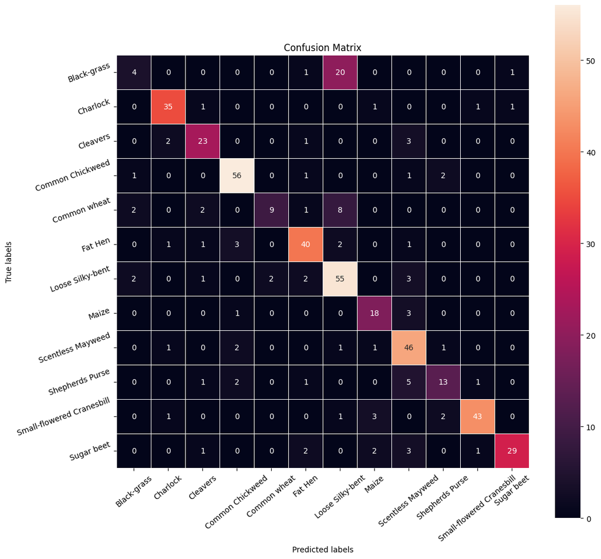

```python
# Obtaining the categorical values from y_test_encoded and y_pred
y_pred_arg2 = np.argmax(y_pred2,axis=1)
y_test_arg2 = np.argmax(y_test_encoded,axis=1)

# Plotting the Confusion Matrix using confusion matrix() function which is also predefined in tensorflow module
confusion_matrix = tf.math.confusion_matrix(y_test_arg2,y_pred_arg2)
f, ax = plt.subplots(figsize=(12, 12))
sns.heatmap(
    confusion_matrix,
    annot=True,
    linewidths=.4,
    fmt="d",
    square=True,
    ax=ax
)
# Setting the labels to both the axes
ax.set_xlabel('Predicted labels');ax.set_ylabel('True labels');
ax.set_title('Confusion Matrix');
ax.xaxis.set_ticklabels(list(enc.classes_),rotation=40)
ax.yaxis.set_ticklabels(list(enc.classes_),rotation=20)
plt.show()
```

**Plotting Classification Report**

```python
from sklearn.metrics import accuracy_score, confusion_matrix
accuracy_score(y_test_arg2, y_pred_arg2)
```

```
0.7810526315789473
```

The prediction accuracy on test data is higher at 78% therefore the model is able to make better prediction.

```python
# Plotting the classification report
from sklearn.metrics import classification_report
print(classification_report((y_test_arg2), y_pred_arg2))
```

```
              precision    recall  f1-score   support

           0       0.44      0.15      0.23        26
           1       0.88      0.90      0.89        39
           2       0.77      0.79      0.78        29
           3       0.88      0.92      0.90        61
           4       0.82      0.41      0.55        22
           5       0.82      0.83      0.82        48
           6       0.63      0.85      0.72        65
           7       0.72      0.82      0.77        22
           8       0.71      0.88      0.79        52
           9       0.72      0.57      0.63        23
          10       0.93      0.86      0.90        50
          11       0.94      0.76      0.84        38

    accuracy                           0.78       475
   macro avg       0.77      0.73      0.73       475
weighted avg       0.78      0.78      0.77       475
```

# Model 3 Building using Transfer Learning: VGG 16

```python
# Clearing backend
from tensorflow.keras import backend
backend.clear_session()

# Fixing the seed for random number generators
import random
np.random.seed(42)
random.seed(42)
tf.random.set_seed(42)
```

```python
def plot_images(images,labels):
  num_classes=12                                                                  # Number of Classes
  categories=np.unique(labels)
  keys=dict(labels['Label'])                                                      # Obtaing the unique classes from y_train
  rows = 3                                                                        # Defining number of rows=3
  cols = 4                                                                        # Defining number of columns=4
  fig = plt.figure(figsize=(10, 8))                                               # Defining the figure size to 10x8
  for i in range(cols):
      for j in range(rows):
          random_index = np.random.randint(0, len(labels))                        # Generating random indices from the data and plotting the images
          ax = fig.add_subplot(rows, cols, i * rows + j + 1)                      # Adding subplots with 3 rows and 4 columns
          ax.imshow(images[random_index, :])                                      # Plotting the image
          ax.set_title(keys[random_index])
  plt.show()
```

```python
images_decreased=[]
height = 64
width = 64
dimensions = (width, height)
for i in range(len(images)):
  images_decreased.append( cv2.resize(images[i], dimensions, interpolation=cv2.INTER_LINEAR))
```

The images have been resized to 64x64 pixels to easen computation

```python
# Applying Gaussian Blur to denoise the images
images_gb=[]
for i in range(len(images)):
  # gb[i] = cv2.cvtColor(images[i], cv2.COLOR_BGR2RGB)
  images_gb.append(cv2.GaussianBlur(images[i], ksize =(3,3),sigmaX =  0))
```

```python
# splitting the data into train, val and test data sets
from sklearn.model_selection import train_test_split
X_temp, X_test, y_temp, y_test = train_test_split(np.array(images_decreased),labels , test_size=0.1, random_state=42,stratify=labels)
X_train, X_val, y_train, y_val = train_test_split(X_temp,y_temp , test_size=0.1, random_state=42,stratify=y_temp)
```

The data sets have nbneen split for training and testing

```python
print(X_train.shape,y_train.shape)
print(X_val.shape,y_val.shape)
print(X_test.shape,y_test.shape)
```

```
(3847, 64, 64, 3) (3847, 1)
(428, 64, 64, 3) (428, 1)
(475, 64, 64, 3) (475, 1)
```

All the split X independent data sets have 64x64 pixels and are all colored. All dependent dta sets are in one color. The X_train and y_train sets have 3847 data entries, the X-Val and y_val sets have 428 rows while X_test and y_test sets have 475 rows.

```python
# Convert labels from names to one hot vectors.
# We have already used encoding methods like onehotencoder and labelencoder earlier so now we will be using a new encoding method called labelBinarizer.
# Labelbinarizer works similar to onehotencoder

from sklearn.preprocessing import LabelBinarizer
enc = LabelBinarizer()
y_train_encoded = enc.fit_transform(y_train)
y_val_encoded=enc.transform(y_val)
y_test_encoded=enc.transform(y_test)
```

All the labels have been dummified (encoded)

```python
# Normalizing the image pixels
X_train_normalized = X_train.astype('float32')/255.0
X_val_normalized = X_val.astype('float32')/255.0
X_test_normalized = X_test.astype('float32')/255.0
```

All the X datasets have been normarlized (standardized)

```python
# data augmentation
# All images to be rescaled by 1/255.
train_datagen = ImageDataGenerator(
                              rotation_range=20,
                              fill_mode='nearest'
                              )
# test_datagen  = ImageDataGenerator(rescale = 1.0/255.)
```

The train data is augmented by rotating. The test dataset is not augmented

```python
# Downloading VGG training model parameters
from keras.applications.vgg16 import VGG16

vgg_model = VGG16(weights='imagenet', include_top = False, input_shape = (64,64,3))
vgg_model.summary()
```

```
Downloading data from https://storage.googleapis.com/tensorflow/keras-applications/vgg16/vgg16_weights_tf_dim_ordering_tf_kernels_notop.h5
Model: "vgg16"
_________________________________________________________________
 Layer (type)                Output Shape              Param #
=================================================================
 input_1 (InputLayer)        [(None, 64, 64, 3)]       0

 block1_conv1 (Conv2D)       (None, 64, 64, 64)        1792

 block1_conv2 (Conv2D)       (None, 64, 64, 64)        36928

 block1_pool (MaxPooling2D)  (None, 32, 32, 64)        0

 block2_conv1 (Conv2D)       (None, 32, 32, 128)       73856

 block2_conv2 (Conv2D)       (None, 32, 32, 128)       147584

 block2_pool (MaxPooling2D)  (None, 16, 16, 128)       0

 block3_conv1 (Conv2D)       (None, 16, 16, 256)       295168

 block3_conv2 (Conv2D)       (None, 16, 16, 256)       590080

 block3_conv3 (Conv2D)       (None, 16, 16, 256)       590080

 block3_pool (MaxPooling2D)  (None, 8, 8, 256)         0

 block4_conv1 (Conv2D)       (None, 8, 8, 512)         1180160

 block4_conv2 (Conv2D)       (None, 8, 8, 512)         2359808

 block4_conv3 (Conv2D)       (None, 8, 8, 512)         2359808

 block4_pool (MaxPooling2D)  (None, 4, 4, 512)         0

 block5_conv1 (Conv2D)       (None, 4, 4, 512)         2359808

 block5_conv2 (Conv2D)       (None, 4, 4, 512)         2359808

 block5_conv3 (Conv2D)       (None, 4, 4, 512)         2359808

 block5_pool (MaxPooling2D)  (None, 2, 2, 512)         0

=================================================================
Total params: 14714688 (56.13 MB)
Trainable params: 14714688 (56.13 MB)
Non-trainable params: 0 (0.00 Byte)
_________________________________________________________________
```

The total trainable VGG model parameters are 14714688.

```python
# Making all the layers of the VGG model non-trainable. i.e. freezing them
for layer in vgg_model.layers:
    layer.trainable = False
```

```python
# model 3 architecture
model3 = Sequential()

# Adding the convolutional part of the VGG16 model from above
model3.add(vgg_model)

# Flattening the output of the VGG16 model because it is from a convolutional layer
model3.add(Flatten())

# Adding a dense output layer
model3.add(Dense(32, activation='relu'))
model3.add(Dropout(0.2))
model3.add(Dense(16, activation='relu'))
model3.add(Dense(12, activation='softmax'))
opt=Adam()
# Compile model3
model3.compile(optimizer=opt, loss='categorical_crossentropy', metrics=['accuracy'])

# Generating the summary of the model3
model3.summary()
```

```
Model: "sequential"
_________________________________________________________________
 Layer (type)                Output Shape              Param #
=================================================================
 vgg16 (Functional)          (None, 2, 2, 512)         14714688

 flatten (Flatten)           (None, 2048)              0

 dense (Dense)               (None, 32)                65568

 dropout (Dropout)           (None, 32)                0

 dense_1 (Dense)             (None, 16)                528

 dense_2 (Dense)             (None, 12)                204

=================================================================
Total params: 14780988 (56.38 MB)
Trainable params: 66300 (258.98 KB)
Non-trainable params: 14714688 (56.13 MB)
_________________________________________________________________
```

This model will only train using 66,300 parameters out of the total of 14,780,988. 14,714.688 parameters have been frozed and will be used as in the original VGG model.

```python
# Model training
# Epochs
epochs = 25
# Batch size
batch_size = 64

history_vgg16 = model3.fit(train_datagen.flow(X_train_normalized,y_train_encoded,
                                       batch_size=batch_size,
                                       seed=42,
                                       shuffle=False),
                    epochs=epochs,
                    steps_per_epoch=X_train_normalized.shape[0] // batch_size,
                    validation_data=(X_val_normalized,y_val_encoded),
                    verbose=1)
```

After 25 epochs of training, the model achieves a prediction of 58% accuracy on training and 52.8% on validation sets

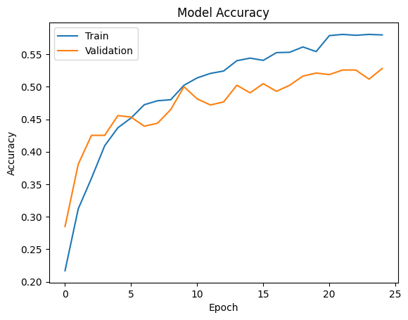

```python
# Plotting performance
plt.plot(history_vgg16.history['accuracy'])
plt.plot(history_vgg16.history['val_accuracy'])
plt.title('Model Accuracy')
plt.ylabel('Accuracy')
plt.xlabel('Epoch')
plt.legend(['Train', 'Validation'], loc='upper left')
plt.show()
```

Initially, both training and validation accuracies increase significantly, indicating the model is learning well. Midway, the validation accuracy plateaus and fluctuates, suggesting the model may be reaching its learning capacity for the validation data or possibly overfitting. Model Performance: The gap between training and validation accuracy by epoch 25 indicates the model is performing reasonably well, but there's some room for improvement in terms of generalization since the accuracy achieved on validation is below 60%.

```python
accuracy = model3.evaluate(X_test_normalized, y_test_encoded, verbose=2)
```

```
15/15 - 1s - loss: 1.3418 - accuracy: 0.5432 - 1s/epoch - 80ms/step
```

```python
# Here we would get the output as probablities for each category
y_pred=model3.predict(X_test_normalized)
```

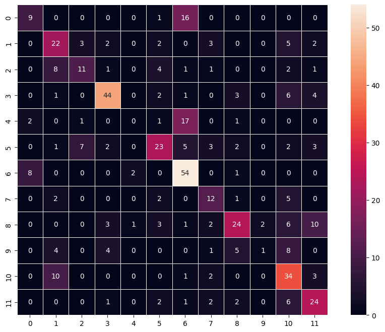

```python
# Obtaining the categorical values from y_test_encoded and y_pred
y_pred_arg=np.argmax(y_pred,axis=1)
y_test_arg=np.argmax(y_test_encoded,axis=1)

# Plotting the Confusion Matrix using confusion matrix() function which is also predefined tensorflow module
confusion_matrix = tf.math.confusion_matrix(y_test_arg,y_pred_arg)
f, ax = plt.subplots(figsize=(12, 8))
sns.heatmap(
    confusion_matrix,
    annot=True,
    linewidths=.4,
    fmt="d",
    square=True,
    ax=ax
)
plt.show()
```

Overall, the model might need further tuning or additional data to improve classification performance, particularly for classes with higher misclassification.

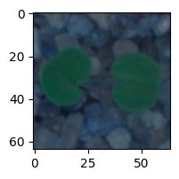

```
Predicted Label ['Small-flowered Cranesbill']
True Label Small-flowered Cranesbill
```

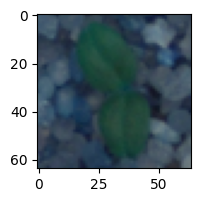

```
Predicted Label ['Fat Hen']
True Label Cleavers
```

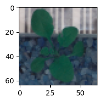

```
Predicted Label ['Charlock']
True Label Shepherds Purse
```

```python
# Visualizing the predicted and correct label of images from test data
plt.figure(figsize=(2,2))
plt.imshow(X_test[2])
plt.show()
print('Predicted Label', enc.inverse_transform(model3.predict((X_test_normalized[2].reshape(1,64,64,3)))))   # reshaping the input image as we are only trying to predict using a single image
print('True Label', enc.inverse_transform(y_test_encoded)[2])                                               # using inverse_transform() to get the output label from the output vector

plt.figure(figsize=(2,2))
plt.imshow(X_test[33])
plt.show()
print('Predicted Label', enc.inverse_transform(model3.predict((X_test_normalized[33].reshape(1,64,64,3)))))  # reshaping the input image as we are only trying to predict using a single image
print('True Label', enc.inverse_transform(y_test_encoded)[33])                                              # using inverse_transform() to get the output label from the output vector

plt.figure(figsize=(2,2))
plt.imshow(X_test[36])
plt.show()
print('Predicted Label', enc.inverse_transform(model3.predict((X_test_normalized[36].reshape(1,64,64,3)))))  # reshaping the input image as we are only trying to predict using a single image
print('True Label', enc.inverse_transform(y_test_encoded)[36])                                              # using inverse_transform() to get the output label from the output vector
```

Out of the 3 images provided to the model, 1 was correctly predicted whille 2 were incorrectly classified. Image 2 was correctly classified as Small-flowered Cranesbill. Shepherds Purse was incorrectly classified as Charlock while Cleavers was classied as Fat Hen.

# Final Model

### Visualizing the prediction using model 2

```
Predicted Label ['Small-flowered Cranesbill']
True Label Small-flowered Cranesbill
```

```
Predicted Label ['Cleavers']
True Label Cleavers
```

```
Predicted Label ['Shepherds Purse']
True Label Shepherds Purse
```

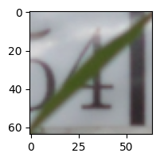

```
Predicted Label ['Small-flowered Cranesbill']
True Label Loose Silky-bent
```

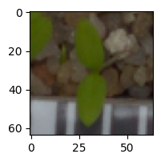

```
Predicted Label ['Cleavers']
True Label Common Chickweed
```

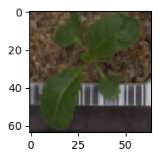

```
Predicted Label ['Shepherds Purse']
True Label Charlock
```

```python
# Visualizing the predicted and correct label of images from test data
plt.figure(figsize=(2,2))
plt.imshow(X_test[2])
plt.show()
print('Predicted Label', enc.inverse_transform(model2.predict((X_test_normalized[2].reshape(1,64,64,3)))))   # reshaping the input image as we are only trying to predict using a single image
print('True Label', enc.inverse_transform(y_test_encoded)[2])                                               # using inverse_transform() to get the output label from the output vector

plt.figure(figsize=(2,2))
plt.imshow(X_test[33])
plt.show()
print('Predicted Label', enc.inverse_transform(model2.predict((X_test_normalized[33].reshape(1,64,64,3)))))  # reshaping the input image as we are only trying to predict using a single image
print('True Label', enc.inverse_transform(y_test_encoded)[33])                                              # using inverse_transform() to get the output label from the output vector

plt.figure(figsize=(2,2))
plt.imshow(X_test[36])
plt.show()
print('Predicted Label', enc.inverse_transform(model2.predict((X_test_normalized[36].reshape(1,64,64,3)))))  # reshaping the input image as we are only trying to predict using a single image
print('True Label', enc.inverse_transform(y_test_encoded)[36])                                              # using inverse_transform() to get the output label from the output vector

# Visualizing the predicted and correct label of images from test data
plt.figure(figsize=(2,2))
plt.imshow(X_test[100])
plt.show()
print('Predicted Label', enc.inverse_transform(model2.predict((X_test_normalized[2].reshape(1,64,64,3)))))   # reshaping the input image as we are only trying to predict using a single image
print('True Label', enc.inverse_transform(y_test_encoded)[100])                                               # using inverse_transform() to get the output label from the output vector

plt.figure(figsize=(2,2))
plt.imshow(X_test[70])
plt.show()
print('Predicted Label', enc.inverse_transform(model2.predict((X_test_normalized[33].reshape(1,64,64,3)))))  # reshaping the input image as we are only trying to predict using a single image
print('True Label', enc.inverse_transform(y_test_encoded)[70])                                              # using inverse_transform() to get the output label from the output vector

plt.figure(figsize=(2,2))
plt.imshow(X_test[50])
plt.show()
print('Predicted Label', enc.inverse_transform(model2.predict((X_test_normalized[36].reshape(1,64,64,3)))))  # reshaping the input image as we are only trying to predict using a single image
print('True Label', enc.inverse_transform(y_test_encoded)[50])                                              # using inverse_transform() to get the output label from the output vector
```

# Actionable Insights

Given dat augmentation helped improve the performance of Model 2, we need to continue conducting data collection and augmentation. This can be done by targeted data collection where more samples for underperforming classes across all models, especially for those frequently misclassified. Implement data augmentation techniques to artificially increase the size and variability of the dataset for challenging classes.

We should continue with model retraining and fine tuning. Frequent retraining -regularly retraining the models with new data to ensure they stay upto date with the latest trends and patterns in the dataset. Also we can hyperparameter tune - by performing hyperparameter optimization for each model to potentially improve accuracy further.

By leveraging these actionable insights, we will not only enhance the current model's performance but also establish a robust framework for continuous improvement.

# Business recommendations

1. Adopt model 2 for deployment: Given its highest overall accuracy and a good balance in class-wise performance, Model 2 should be preferred for deployment.
2. Improve data collection for challenging classes: There is need to focus on classes with high misclassification rates by collecting more representative data or refining the feature extraction methods. For example, classes like Black-grass and Cleavers in Model 1 could benefit from additional data and analysis.
3. Continuous monitoring and retraining: There is need for regular monitoring of the model's performance in production and retrain it with new data to ensure it adapts to any changes in the distribution of classes.
4. Investigate misclassifications: There is need to perform a detailed analysis of the misclassified samples to understand patterns and potentially refine the model's training process.

By implementing these recommendations, we can leverage the strengths of the most effective model while addressing areas of improvement to ensure optimal performance in real world scenarios.